# Homework 6

Siyan Wen

2023-11-30

```r
library(tidyverse)
library(modelr)
library(mgcv)
set.seed(1)
```

# Problem 2

#### Download the data.

```r
weather_df =
  rnoaa::meteo_pull_monitors(
    c("USW00094728"),
    var = c("PRCP", "TMIN", "TMAX"),
    date_min = "2022-01-01",
    date_max = "2022-12-31") |>
  mutate(
    name = recode(id, USW00094728 = "CentralPark_NY"),
    tmin = tmin / 10,
    tmax = tmax / 10) |>
  select(name, id, everything())
```

```
## using cached file: /Users/wensiyan/Library/Caches/org.R-project.R/R/rnoaa/noaa_ghcnd/USW00094728.dly
```

```
## date created (size, mb): 2023-09-28 15:38:36.830949 (8.524)
```

```
## file min/max dates: 1869-01-01 / 2023-09-30
```

#### Bootstrap and SLR

```r
bootstrap_result_glance=
  weather_df|>
  modelr::bootstrap(n = 5000) |>
  mutate(
    models = map(strap, \(df) lm(tmax ~ tmin +prcp , data = df)),
    results = map(models, broom::glance)) |>
  select(results) |>
  unnest(results)


bootstrap_result_tidy=
  weather_df|>
  modelr::bootstrap(n = 5000) |>
  mutate(
    models = map(strap, \(df) lm(tmax ~ tmin +prcp , data = df)),
    results = map(models, broom::tidy)) |>
  select(results) |>
  unnest(results)|>
  select(term,estimate)|>
  pivot_wider(
    names_from=term,
    values_from=estimate
  )|>
  unnest()
```

#### Show distribution

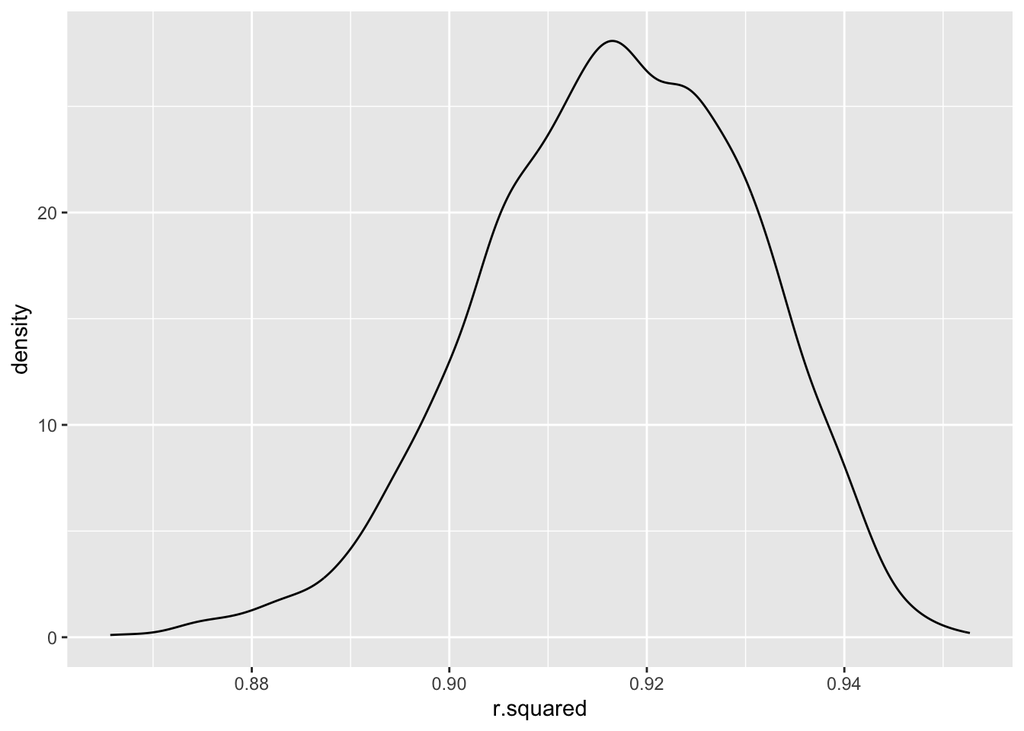

```r
r.squared_distribution=
  bootstrap_result_glance|>
  ggplot(aes(x = r.squared)) + geom_density()
print(r.squared_distribution)
```

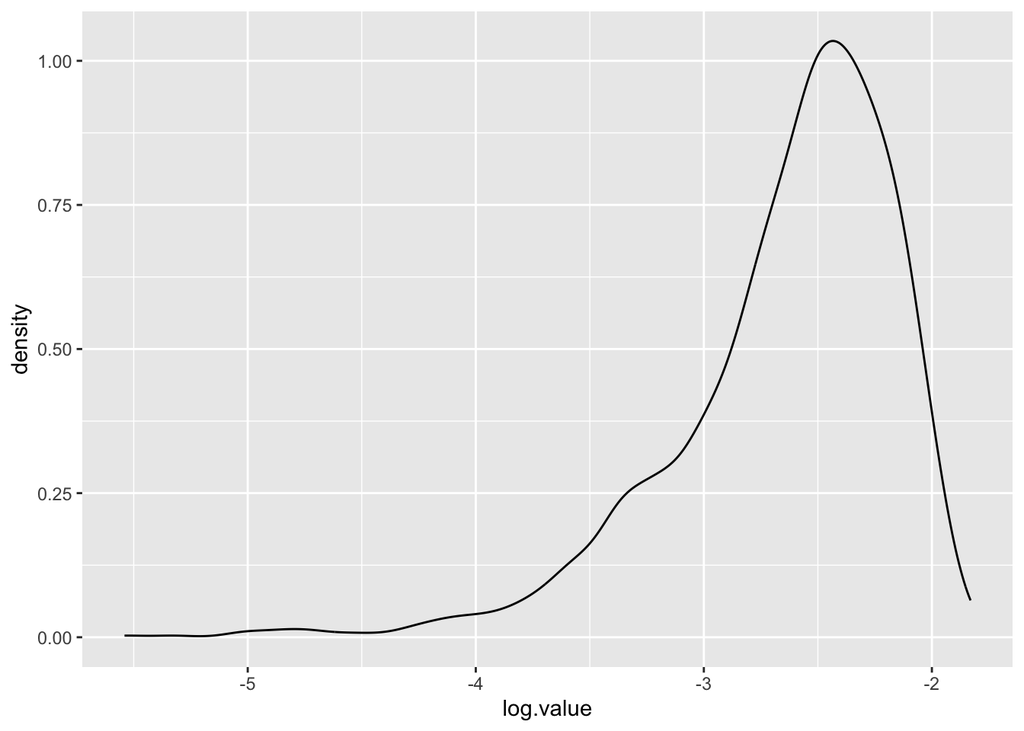

```r
log_distribution=
  bootstrap_result_tidy|>
  mutate(log.value=log10(tmin*prcp))|>
  ggplot(aes(x = log.value)) + geom_density()
print(log_distribution)
```

**Description:**

The distribution of “log” exhibits a even more notable heavy tail extending to the low values. This is an uni-modal and left/negative skewed distribution. This shows a tendency for the majority of values to cluster on the right side, with a tail extending towards the lower values.

#### Confidence interval

```r
bootstrap_result_glance |>
  summarize(
    ci_lower = quantile(r.squared, 0.025),
    ci_upper = quantile(r.squared, 0.975))
```

```
## # A tibble: 1 × 2
##   ci_lower ci_upper
##      <dbl>    <dbl>
## 1    0.889    0.941
```

```r
bootstrap_result_tidy|>
  mutate(log.value=log10(tmin*prcp))|>
  summarize(
    ci_lower_log.value = quantile(log.value, 0.025,na.rm = TRUE),
    ci_upper_log.value = quantile(log.value, 0.975,na.rm = TRUE)
    )
```

```
## # A tibble: 1 × 2
##   ci_lower_log.value ci_upper_log.value
##                <dbl>              <dbl>
## 1              -3.86              -2.00
```

# Problem 3

#### Load and clean the data

```r
birthweight=
  read_csv("data/birthweight.csv")|>
  janitor::clean_names()|>
  select(bwt,blength,gaweeks,bhead,babysex,mrace)|>
  mutate(babysex=as.factor(babysex))
# Check for missing data
missing_data_summary=
  birthweight|>
  summarise_all(~ sum(is.na(.))) |>
  gather(key = "variable", value = "missing_count") |>
  filter(missing_count > 0)
print(missing_data_summary)
```

```
## # A tibble: 0 × 2
## # ℹ 2 variables: variable <chr>, missing_count <int>
```

Based on the results from `Check for missing data`, there is no missing data in the remaining dataset of interest.

#### My SLR Model

From my point of view, baby’s birthweight involves considering various factors that may influence it including baby’s length at birth and baby’s head circumference at birth. To explore my SLR model, let’s first take a look at the distribution of birthweight with each of factor of interest.

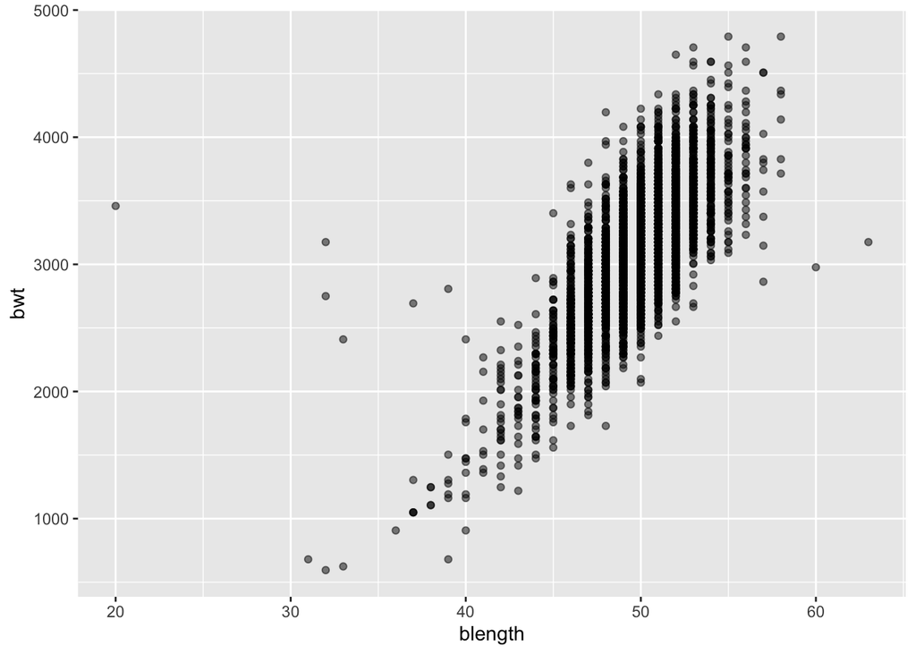

```r
birthweight |>
  ggplot(aes(x=blength, y=bwt)) +
  geom_point(alpha = .5)
```

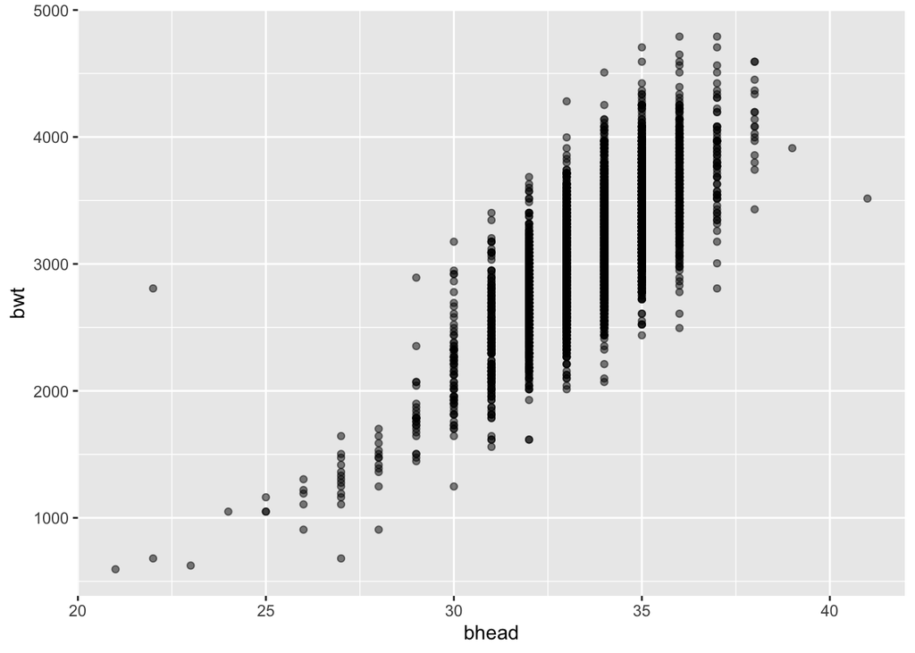

```r
birthweight |>
  ggplot(aes(x=bhead, y=bwt)) +
  geom_point(alpha = .5)
```

According to the scatterplots of the distribution above, we can see that there might be linear relationship between baby’s birthweight with baby’s length and baby’s birthweight with baby’s head circumference. Therefore, my simple linear regression will be like this

```r
linear_own = lm(bwt ~ blength+bhead, data = birthweight)
```

#### Plot of Model Residuals against Fitted Values

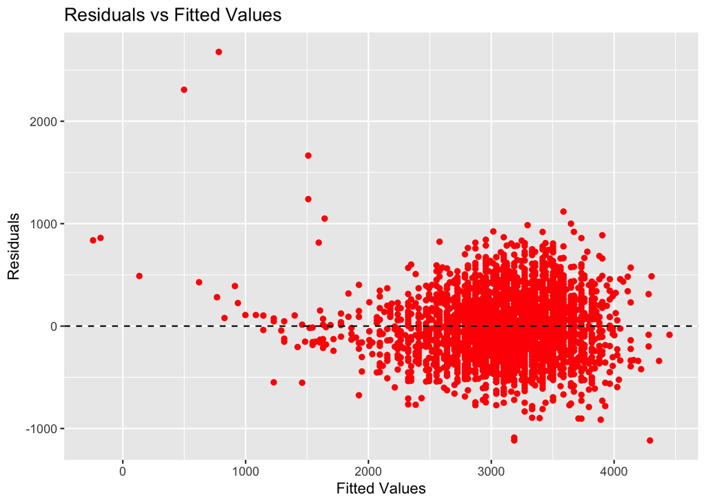

```r
birthweight|>
  add_predictions(linear_own) |>
  add_residuals(linear_own)|>
  ggplot(aes(x = pred, y = resid) ) + geom_point(color="red")+
  geom_hline(yintercept = 0, linetype = "dashed", color = "black") +
  labs(title = "Residuals vs Fitted Values",
       x = "Fitted Values",
       y = "Residuals")
```

#### Two other models

```r
model2 <- lm(bwt ~ blength + gaweeks, data = birthweight)
model3 <- lm(bwt ~ bhead * blength * babysex, data = birthweight)
```

#### Cross Validation

```r
cv_df =
  crossv_mc(birthweight, 80) |>
  mutate(
    train = map(train, as_tibble),
    test = map(test, as_tibble))
cv_df =
  cv_df |>
  mutate(
    linear_own  = map(train, \(df) lm(bwt ~ blength+bhead, data = df)),
    model2    = map(train, \(df) lm(bwt ~ blength + gaweeks, data = df)),
    model3  = map(train, \(df) lm(bwt ~ bhead * blength * babysex, data = df))) |>
  mutate(
    rmse_linear_own = map2_dbl(linear_own, test, \(mod, df) rmse(model = mod, data = df)),
    rmse_model2    = map2_dbl(model2, test, \(mod, df) rmse(model = mod, data = df)),
    rmse_model3 = map2_dbl(model3, test, \(mod, df) rmse(model = mod, data = df)))
```

Finally, plot the prediction error distribution for each candidate model.

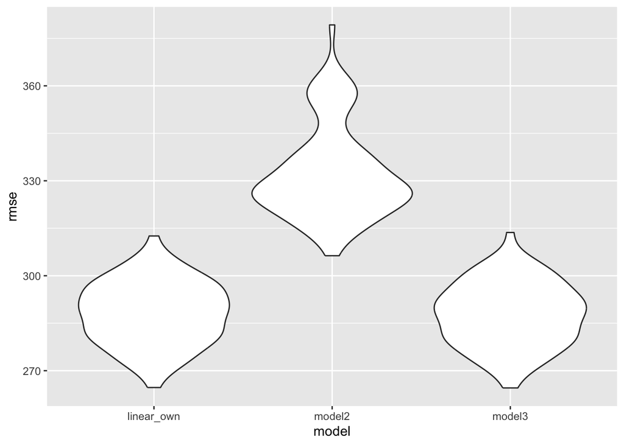

```r
cv_df |>
  select(starts_with("rmse")) |>
  pivot_longer(
    everything(),
    names_to = "model",
    values_to = "rmse",
    names_prefix = "rmse_") |>
  mutate(model = fct_inorder(model)) |>
  ggplot(aes(x = model, y = rmse)) + geom_violin()
```